# First class

# EXERCISES

## geom_point

If you have two continuous variables, the geom_point is the preferred option to graph

Try plotting the bill_length_mm in the x axis vs the bill_depth_mm

```r
penguins %>%
  ggplot(aes(x = _____________,
             y = _____________)) +
  geom_point()
```

```r
penguins %>%
  ggplot(aes(x = _____________,
             y = _____________,
             color = _________)) +
  geom_point()
```

and we can add several additional aesthetics layers, as

shape = for discrete or categorical variables, as sex size = for continuous variables, as body_mass_g

and also we can add more geom layers. For example, we can add a regression line to explore the correlation between the plotted variables.

Try adding a geom_smooth(method = “lm”) after the last geom and check the results

```r
penguins %>%
  ggplot(aes(x = bill_length_mm,
             y = bill_depth_mm)) +
  geom_point() +
  ________________
```

What can you conclude about the relationship between these two variables?

Now try disaggregating by species.

Hint: mark the species with colors

We can add more variables depending on your nature.

For example, we can change the size of each point according to some numerical variable, such as the body_mass_g

try completing this code

```r
penguins %>%
  ggplot(aes(x = bill_length_mm,
             y = bill_depth_mm,
             color = species,
             size = ___________) +
  geom_point()
```

## Tuning your graph

### Themes

You can change the theme of the graph, the visual appearence, changing the layer that control this, with the commando *theme* and choosing your theme of preference

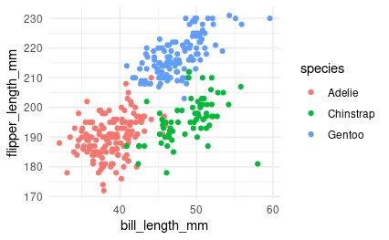

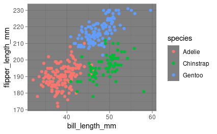

Try others!

try theme_linedraw() theme_light()

You can also install more themes or [create your own theme](https://emanuelaf.github.io/own-ggplot-theme.html)

Some packages with additional themes are:

[ggpubr](http://www.sthda.com/english/articles/24-ggpubr-publication-ready-plots/) (I use mostly the minimal and some of the ggpubr package) and [ggthemes](https://rpubs.com/Mentors_Ubiqum/ggthemes_1)

To install use

```r
pacman::p_load(ggthemes)
```

and then

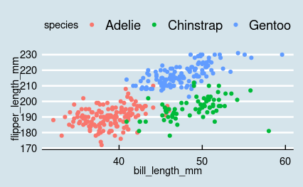

You can try these themes:  
- ggthemes::theme_solarized() - ggthemes::theme_excel()

### Headings and labels

You can add and change the labels with labs()

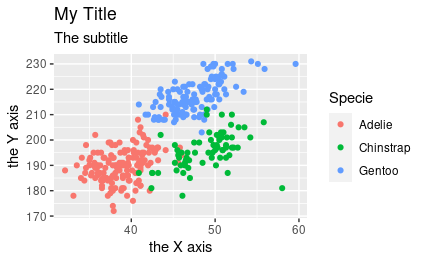

Try to answer these questions:

What is the relationship between Penguin mass vs. flipper length ?

And between Flipper length vs. bill length?

# Notation Note

You will find this kind of notation in books and posts, where the data goes inside the ggplot command. For example:

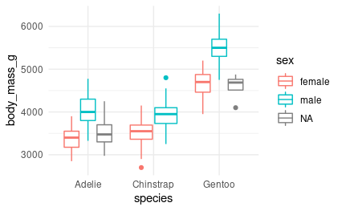

I prefer to leave the data out of the ggplot command, since it’s easier to perform some data transformation and then plot it.